# Tugas 1 Praktikum MPDW

Qurrota A’yunina

2026-08-28

```r
library(forecast)
library(graphics)
library(TTR)
library(TSA)
library(ggplot2)

# Impor data 100 jam yang sudah dirata-ratakan
data1 <- read.csv ("C://Users//USER//OneDrive//ドキュメント//MPDW 1//mpdw//Tugas 1 Praktikum MPDW//Data Suhu 100 Pertama.csv")

colnames(data1)
```

```
## [1] "Date.Time" "T..degC."
```

```r
# Mengubah ke objek time series
data1.ts <- ts(data1$`T..degC`)
```

```r
# Bagi data latih (80% = 80 jam) dan data uji (20% = 20 jam)
n <- nrow(data1)
n_train <- floor(0.8 * n)

training_ma <- data1[1:n_train, ]
testing_ma  <- data1[(n_train+1):n, ]

train_ma.ts <- ts(training_ma$`T..degC`)
test_ma.ts  <- ts(testing_ma$`T..degC`)

# 1. Single Moving Average (SMA n=4)
data.sma <- SMA(train_ma.ts, n = 4)
data.ramal <- c(NA, data.sma)
n_test <- length(test_ma.ts)

data.gab <- cbind(
  aktual = c(data1.ts),
  pemulusan = c(data.sma, rep(NA, n_test)),
  ramalan = c(data.ramal, rep(data.ramal[length(data.ramal)], n_test - 1))
)

# 2. Double Moving Average (DMA n=4)
dma <- SMA(data.sma, n = 4)
At <- 2*data.sma - dma
Bt <- 2/(4-1)*(data.sma - dma)
data.dma <- At + Bt
data.ramal2 <- c(NA, data.dma)

f <- c()
for (i in 1:n_test) {
  f[i] <- At[length(At)] + Bt[length(Bt)] * i
}

data.gab2 <- cbind(
  aktual = c(data1.ts),
  pemulusan1 = c(data.sma, rep(NA, n_test)),
  pemulusan2 = c(dma, rep(NA, n_test)),
  At = c(At, rep(NA, n_test)),
  Bt = c(Bt, rep(NA, n_test)),
  ramalan = c(data.ramal2, f[-1])
)

# 3. Single Exponential Smoothing (SES Optimum)
HWopt <- HoltWinters(train_ma.ts, gamma = FALSE, beta = FALSE, alpha = NULL)
ramalanopt <- forecast(HWopt, h = n_test)

# 4. Double Exponential Smoothing (DES Optimum)
des.opt <- HoltWinters(train_ma.ts, gamma = FALSE, alpha = NULL, beta = NULL)
ramalandesopt <- forecast(des.opt, h = n_test)

# Hitung Akurasi Data Uji
error_test.sma <- test_ma.ts - data.gab[(n_train+1):n, 3]
error_test.dma <- test_ma.ts - data.gab2[(n_train+1):n, 6]
selisihsesopt  <- ramalanopt$mean - testing_ma$`T..degC`
selisihdesopt  <- ramalandesopt$mean - testing_ma$`T..degC`

tabel_akurasi <- data.frame(
  Metode = c("SMA (n=4)", "DMA (n=4)", "SES Optimum", "DES Optimum"),
  MSE  = c(mean(error_test.sma^2), mean(error_test.dma^2), mean(selisihsesopt^2), mean(selisihdesopt^2)),
  MAPE = c(mean(abs(error_test.sma/test_ma.ts)*100), mean(abs(error_test.dma/test_ma.ts)*100),
          mean(abs(selisihsesopt/testing_ma$`T..degC`)*100), mean(abs(selisihdesopt/testing_ma$`T..degC`)*100))
)
tabel_akurasi
```

```
##        Metode        MSE      MAPE
## 1   SMA (n=4) 0.18869653  33.83985
## 2   DMA (n=4) 4.39398157 127.79829
## 3 SES Optimum 0.08018004  23.03627
## 4 DES Optimum 0.70632015  47.93066
```

- SMA (n=4) menghasilkan MSE sebesar 0,1887 dan MAPE 33,84%. Artinya, metode ini memiliki tingkat kesalahan yang cukup rendah, tetapi masih lebih besar dibandingkan SES.
- DMA (n=4) memiliki MSE 4,3940 dan MAPE 127,80%, yang merupakan nilai kesalahan paling besar. Jadi, DMA merupakan metode dengan kinerja paling buruk pada data ini.
- SES Optimum memiliki MSE 0,0802 dan MAPE 23,04%, keduanya merupakan nilai terkecil dibandingkan metode lainnya. Jadi, SES Optimum merupakan metode terbaik dalam melakukan peramalan pada data tersebut.
- DES Optimum menghasilkan MSE 0,7063 dan MAPE 47,93%. Kinerjanya lebih buruk dibandingkan SMA dan SES, tetapi masih lebih baik daripada DMA.

Berdasarkan nilai MSE dan MAPE, metode SES Optimum memberikan hasil peramalan terbaik karena memiliki nilai kesalahan paling rendah, yaitu MSE sebesar 0,0802 dan MAPE sebesar 23,04%. Sementara itu, DMA (n=4) memberikan hasil peramalan terburuk dengan MSE sebesar 4,3940 dan MAPE sebesar 127,80%. Dengan demikian, metode SES Optimum dipilih sebagai metode peramalan yang paling sesuai untuk data yang digunakan.

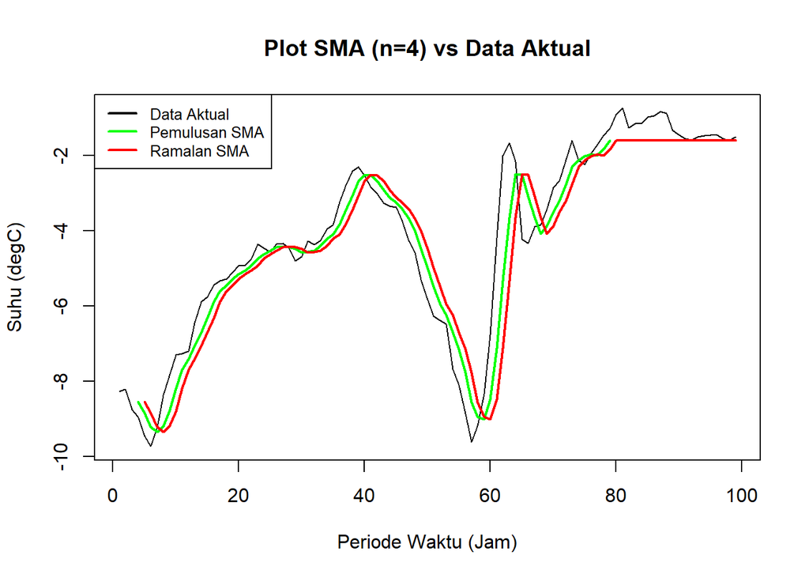

```r
# Plot Single Moving Average (SMA n=4)
ts.plot(data1.ts, xlab = "Periode Waktu (Jam)", ylab = "Suhu (degC)",
        main = "Plot SMA (n=4) vs Data Aktual")
lines(data.gab[, 2], col = "green", lw = 2) # Pemulusan
lines(data.gab[, 3], col = "red", lw = 2)   # Ramalan
legend("topleft", c("Data Aktual", "Pemulusan SMA", "Ramalan SMA"),
       col = c("black", "green", "red"), lty = 1, lwd = 2, cex = 0.8)
```

- Garis hitam (Data Aktual) menunjukkan perubahan suhu yang sebenarnya. Terlihat suhu mengalami beberapa fluktuasi, terutama penurunan yang cukup tajam sekitar periode 50–60, kemudian meningkat kembali secara tajam sekitar 60–65.

- Garis hijau (Pemulusan SMA) terlihat lebih halus dibandingkan data aktual karena SMA menggunakan rata-rata 4 periode untuk mengurangi fluktuasi jangka pendek.
- Garis merah (Ramalan SMA) cenderung mengikuti pola data aktual, tetapi terlihat lebih lambat dalam merespons perubahan yang tiba-tiba. Misalnya, ketika suhu turun atau naik secara drastis, garis ramalan tidak langsung mengikuti perubahan tersebut.
- Pada bagian akhir periode, data aktual relatif berada di sekitar −2 sampai −1,5°C, sementara hasil pemulusan dan ramalan SMA juga cenderung mendekati −1,5°C.

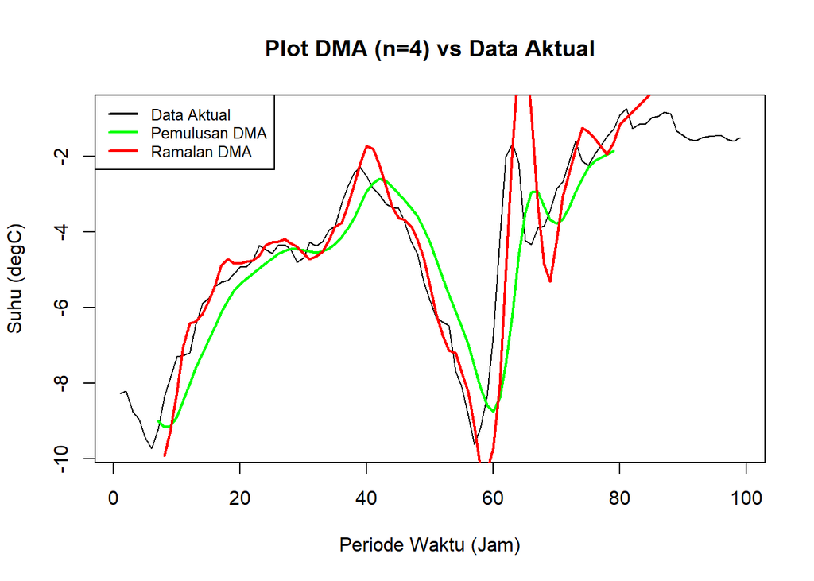

```r
# Plot Double Moving Average (DMA n=4)
ts.plot(data1.ts, xlab = "Periode Waktu (Jam)", ylab = "Suhu (degC)",
        main = "Plot DMA (n=4) vs Data Aktual")
lines(data.gab2[, 3], col = "green", lw = 2) # Pemulusan 2
lines(data.gab2[, 6], col = "red", lw = 2)   # Ramalan
legend("topleft", c("Data Aktual", "Pemulusan DMA", "Ramalan DMA"),
       col = c("black", "green", "red"), lty = 1, lwd = 2, cex = 0.8)
```

- Garis hitam (Data Aktual) menunjukkan pergerakan suhu udara yang sebenarnya sepanjang 100 periode waktu (jam). Terlihat suhu mengalami beberapa fluktuasi tajam, terutama penurunan drastis hingga mencapai sekitar -10°C pada periode 50–60, lalu melonjak naik dengan sangat cepat melebihi -2°C sekitar periode 60–65.
- Garis hijau (Pemulusan DMA) berada di antara fluktuasi data aktual dan berfungsi menangkap pola tren utama. Garis ini terlihat lebih halus (*smooth*) dibandingkan data aktual karena proses perataan ganda dua kali dengan n=4.
- Garis merah (Ramalan DMA) merespons perubahan tren dengan lebih cepat dibandingkan SMA biasa, tetapi menunjukkan sifat *overshooting* (penyesuaian ekstrem) pada area titik balik. Terlihat ketika terjadi pergerakan ekstrem pada periode 50–60 dan 60–65, garis ramalan DMA meluncur jatuh sangat jauh ke bawah melebihi -10°C lalu melesat sangat tinggi ke atas menembus grafik.
- Pada periode data uji (setelah periode 80), garis pemulusan berhenti pada periode latih (80 jam). Hasil ramalan DMA (garis merah) terlihat menerus memproyeksikan garis tren ke atas secara konstan (melenceng tinggi menembus grafik), sementara data aktual sebenarnya cenderung melandai dan bergerak stabil di kisaran -2°C sampai -1,5°C. Hal inilah yang menyebabkan kesalahan peramalan (MSE) DMA menjadi sangat besar.

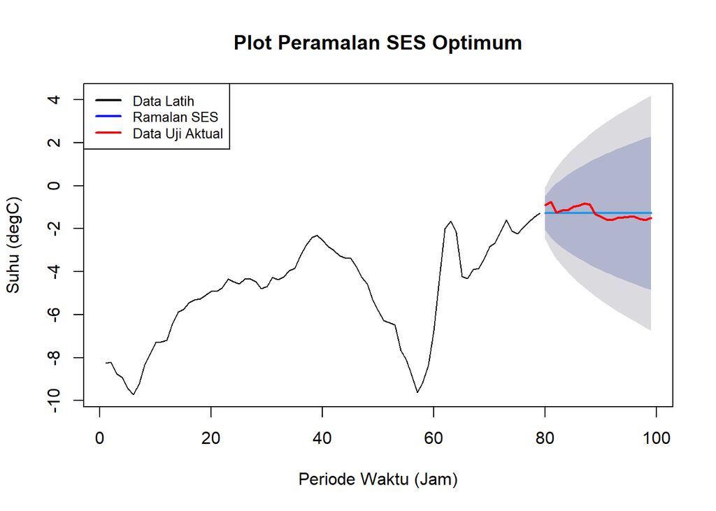

```r
# # Plot Single Exponential Smoothing (SES Optimum)
test_ma.ts <- ts(testing_ma$`T..degC`, start = n_train + 1)

plot(ramalanopt, main = "Plot Peramalan SES Optimum",
     xlab = "Periode Waktu (Jam)", ylab = "Suhu (degC)")
lines(test_ma.ts, col = "red", lwd = 2)
legend("topleft", c("Data Latih", "Ramalan SES", "Data Uji Aktual"),
       col = c("black", "blue", "red"), lty = 1, lwd = 2, cex = 0.8)
```

- Garis hitam (Data Latih) menggambarkan pola historis suhu per jam selama 80 jam pertama. Suhu mengalami fluktuasi signifikan, diawali penurunan ekstrem hingga mendekati -10°C di sekitar periode ke-60, lalu melonjak naik dan mulai bergerak stabil di kisaran -2°C mendekati jam ke-80.

- Garis biru (Ramalan SES) membentuk garis lurus mendaftar (flat forecast) di kisaran suhu -1,2°C untuk periode 81–100. Hal ini sesuai dengan sifat khas metode Single Exponential Smoothing (SES) yang memberikan nilai prediksi konstan untuk horizon waktu mendatang pada data stasioner.
- Garis merah (Data Uji Aktual) bergerak saling berdekatan dan berhimpitan sangat rapat dengan garis biru hasil ramalan SES pada kisaran -1,5°C hingga -1,0°C.
- Area abu-abu (Interval Kepercayaan) memuat seluruh pergerakan garis merah data uji aktual di dalamnya. Kedekatan garis merah dengan garis biru ini membuktikan presisi peramalan SES yang sangat tinggi dengan tingkat kesalahan paling minimal (MSE = 0,08018 dan MAPE = 23,04%).

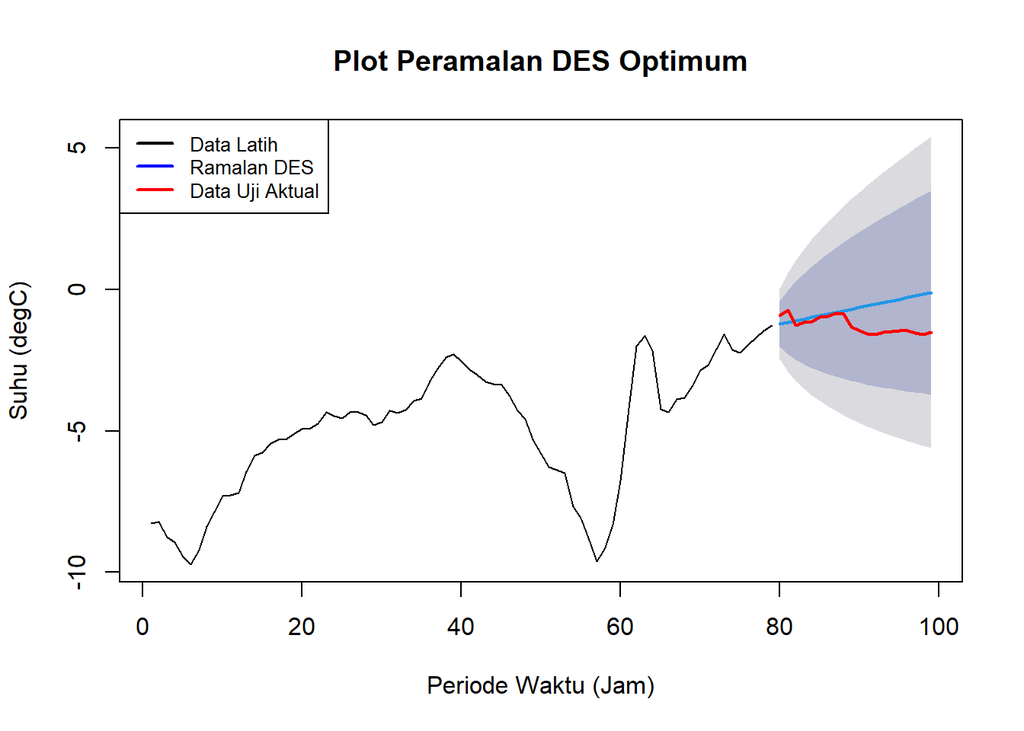

```r
# Plot Double Exponential Smoothing (DES Optimum)
test_ma.ts <- ts(testing_ma$`T..degC`, start = n_train + 1)

plot(ramalandesopt, main = "Plot Peramalan DES Optimum",
     xlab = "Periode Waktu (Jam)", ylab = "Suhu (degC)")
lines(test_ma.ts, col = "red", lwd = 2)
legend("topleft", c("Data Latih", "Ramalan DES", "Data Uji Aktual"),
       col = c("black", "blue", "red"), lty = 1, lwd = 2, cex = 0.8)
```

- Garis hitam (Data Latih) memperlihatkan pergerakan suhu udara selama 80 jam pertama, yang mengalami fluktuasi besar dari penurunan drastis mendekati -10°C lalu naik kembali menuju -1,2°C di akhir data latih.

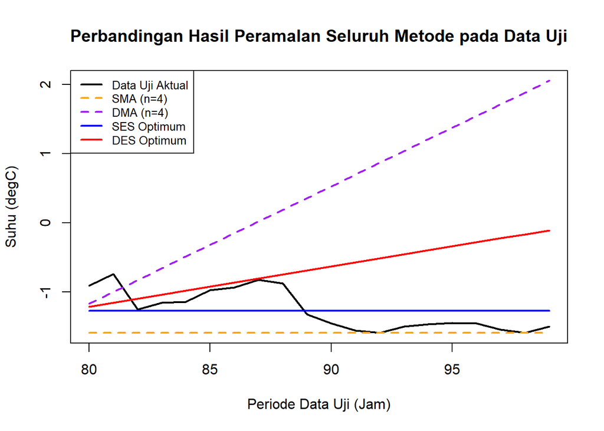

```r
# Tentukan indeks sumbu X untuk data uji (81 sampai 100)
x_uji <- (n_train + 1):n

# 1. Plot Utama Data Uji Aktual
plot(x_uji, test_ma.ts, type = "l", col = "black", lwd = 2,
     ylim = range(c(test_ma.ts, data.gab[x_uji, 3], data.gab2[x_uji, 6],
                    ramalanopt$mean, ramalandesopt$mean), na.rm = TRUE),
     xlab = "Periode Data Uji (Jam)", ylab = "Suhu (degC)",
     main = "Perbandingan Hasil Peramalan Seluruh Metode pada Data Uji")

# 2. Tambahkan Garis Ramalan Masing-masing Metode (Pakai x_uji)
lines(x_uji, data.gab[x_uji, 3], col = "orange", lwd = 2, lty = 2) # SMA
lines(x_uji, data.gab2[x_uji, 6], col = "purple", lwd = 2, lty = 2) # DMA
lines(x_uji, as.numeric(ramalanopt$mean), col = "blue", lwd = 2)   # SES
lines(x_uji, as.numeric(ramalandesopt$mean), col = "red", lwd = 2)  # DES

# 3. Legenda
legend("topleft",
       legend = c("Data Uji Aktual", "SMA (n=4)", "DMA (n=4)", "SES Optimum", "DES Optimum"),
       col = c("black", "orange", "purple", "blue", "red"),
       lty = c(1, 2, 2, 1, 1), lwd = 2, cex = 0.8)
```

- Garis hitam (Data Uji Aktual) memperlihatkan pergerakan suhu udara yang sebenarnya pada jam ke-81 hingga jam ke-100, yang cenderung stasioner dan berfluktuasi melandai di kisaran suhu -1.6°C hingga -0.8°C.

- Garis biru (SES Optimum) berada paling rapat dan konsisten memotong pertengahan pola fluktuasi garis data aktual di kisaran -1.2°C. Hal ini membuktikan mengapa metode SES Optimum menjadi **metode terbaik** dengan kesalahan terendah (**MSE = 0.08018**).
- Garis oranye putus-putus (SMA $n=4$) membentuk garis konstan mendaftar di sekitar -1.6°C. Meskipun bersifat konstan seperti SES, posisinya sedikit lebih rendah di bawah rata-rata fluktuasi data aktual sehingga nilai MSE-nya sedikit lebih tinggi (**MSE = 0.18870**).
- Garis merah (DES Optimum) & Garis ungu putus-putus (DMA $n=4$)** membentuk proyeksi garis lurus yang terus naik (ber-tren positif) menjauhi data aktual. Proyeksi tren yang terlalu curam ini (*overshooting*) menyebabkan kesalahan peramalan yang sangat besar pada DMA (**MSE = 4.39398**) dan DES (**MSE = 0.70632**), karena data suhu aktual sebenarnya tidak memiliki tren naik jangka panjang.

Kesimpulan: